# Investigando as causas de ausências em escolas de ensino médio: Uma análise com o modelo de regressão Binomial Negativo

Samuel M. Medeiros[^1]

04 fevereiro, 2023

Abstract

Este trabalho apresenta uma investigação sobre as causas de ausências em escolas de ensino médio em Portugal. A presença regular dos alunos nas aulas é fundamental para o sucesso acadêmico e o desenvolvimento pessoal. Portanto, é importante identificar as causas que levam a estas ausências. Para fazer isso, é apresentado um modelo de regressão Binomial Negativo para examinar a relação entre as características domésticas e pessoais dos alunos e suas faltas às aulas. Este modelo permitiu que fosse avaliado a influência dessas características na frequência dos alunos nas aulas e identificassem possíveis soluções para melhorar a presença dos estudantes.

# Introdução

A presença regular dos alunos nas aulas é fundamental para o sucesso acadêmico e o desenvolvimento pessoal. No entanto, ausências frequentes podem prejudicar o aprendizado e o desempenho escolar. É importante, portanto, identificar as causas dessas ausências e encontrar soluções para minimizá-las.

Nesse sentido, este trabalho se propõe a investigar as causas de ausências em escolas de ensino médio de Portugal. Será utilizado o modelo de regressão Binomial Negativo para relacionar características domésticas e pessoais dos alunos com suas faltas às aulas. A análise dos resultados permitirá avaliar a influência dessas características na frequência dos alunos nas aulas e identificar possíveis soluções para melhorar a presença dos estudantes.

Este trabalho se baseia em uma pesquisa original que tenta estabelecer uma relação entre o consumo de álcool e as notas baixas dos estudantes (Cortez e Silva 2008), foram utilizados modelos com tarefas de classificação binária/cinco níveis e regressão.

Este estudo apresenta uma metodologia baseada em modelos de regressão generalizados que se adequa ao escopo do assunto em questão e fornece uma contribuição significativa para a compreensão das causas de ausência nas escolas de ensino médio, apresentando resultados importantes para entender dinâmicas sociais quanto a relação aluno escola na atualidade.

# Metodologia

## Modelo

O modelo de regressão binomial negativo é um tipo de modelo de regressão que é usado para prever uma variável inteira variando de 0 a infinito, ou seja, uma variável que pode ter apenas valores como contagem (por exemplo, número de biscoitos em um pacote, ou número de sucessos ou falhas em um evento, etc.). Nesse modelo, a probabilidade de ocorrência da variável é relacionada a uma ou mais variáveis independentes através de uma função matemática.

No caso de uma única variável independente, a função matemática é geralmente a função logística, que mapeia a entrada da variável independente em uma probabilidade entre 0 e 1. No caso de várias variáveis independentes, o modelo de regressão binomial negativo pode ser implementado como uma regressão logística múltipla.

A função da regressão binomial negativa é dada por:

$$\text{log}(y_i) = \beta_0 + \beta_1
x_{1,i} + \beta_2 x_{2,i} + \cdots + \beta_k x_{k,i}$$

onde $y_i$ é a resposta observada a ser estudada, $x_{j,i}$ é a j-ésima variável explicativa e $\beta_j$ são os parâmetros do modelo a serem estimados. A função densidade da Binomial Negativa é dada por:

$$f(y_i|\mu_i,\phi) = \frac{\Gamma(\phi +
y_i)}{\Gamma(\phi)\Gamma(y_i+1)}\left(\frac{\mu_i}{\phi+\mu_i}\right)^{y_i}\left(\frac{\phi}{\phi+\mu_i}\right)^{\phi},
\quad y_i = 0,1,2,..$$
Onde $y_i$ representa o número de faltas para cada aluno.

## Seleção de Variáveis

A análise dos dados originais foi revisada com o objetivo de selecionar as variáveis mais relevantes para explicar o número de faltas. Esta seleção foi baseada em conhecimentos prévios sobre o assunto e levou em consideração a importância de cada variável para a explicação do fenômeno estudado.

A partir desse subconjunto foi utilizado o método backward. O método de seleção de variáveis backward, também conhecido como eliminação backwards, é uma técnica de seleção de variáveis que começa com todas as variáveis potenciais incluídas no modelo e, aos poucos, remove as variáveis menos importantes. O processo é repetido até que apenas as variáveis mais significativas estejam presentes no modelo. A critério para a eliminação de uma variável pode ser baseada em estatísticas, como o p-valor, ou em outras métricas de desempenho do modelo, como o erro de predição ou o coeficiente de determinação. O método de seleção de variáveis backward é útil quando há uma grande quantidade de variáveis disponíveis e se deseja reduzir o número de variáveis sem sacrificar a capacidade de explicar a variável resposta.

Considerando o novo conjunto então seleção a partir de comparação de modelos resultou em um número ainda menor de variáveis selecionadas, sendo essas apresentadas na sessão seguinte, Banco de Dados.

# Banco de Dados

## Variáveis selecionadas

Com base em um banco de dados obtido na plataforma Kaggle sobre o consumo de álcool entre estudantes e suas respectivas notas em matemática e português, este estudo foi realizado para compreender a relação entre as características pessoais e sociais dos alunos e o número de faltas em um ano (Variável do tipo numérica inteiro), O banco de dados está disponível no [repositório](https://github.com/SammyMar/MLG) do *GitHub* para este trabalho.

Propondo um modelo com as faltas como variável resposta, a partir de conhecimentos prévios e de métodos de seleção de variáveis discutidos na seção *Metodologia*, tentamos explicar a variável dependente através das variáveis independentes selecionadas, fazendo uma filtragem em relação as variáveis originais nos resta então as apresentadas na Tabela 1.

Variaveis selecionadas para analise

| Codigo | Variavel | Classificacao |
| --- | --- | --- |
| school | Escola | Categorica |
| Sex | Sexo | Categorica |
| Medu | Educacao da mae | Categorica |
| reason | Razao para escolher a escola | Categorica |
| Dalc | Consumo de alcool em dias uteis | Categorica |
| Age | Idade | Numerica |
| Internet | Acesso a internet em casa | Categorica |

## Exploratória dos dados selecionados

Nota-se que o número de observações para as duas escolas é bem discrepante, ou seja, um número muito inferior de observações da escola ‘MS’, ou Mousinho da Silveis, em relação a escola Gabriel Pereira (GP). Levando esse fato em consideração, dois modelos foram analisados, com e sem a variável ‘School’, sendo o resultado dos dois modelos apresentados no trabalho.

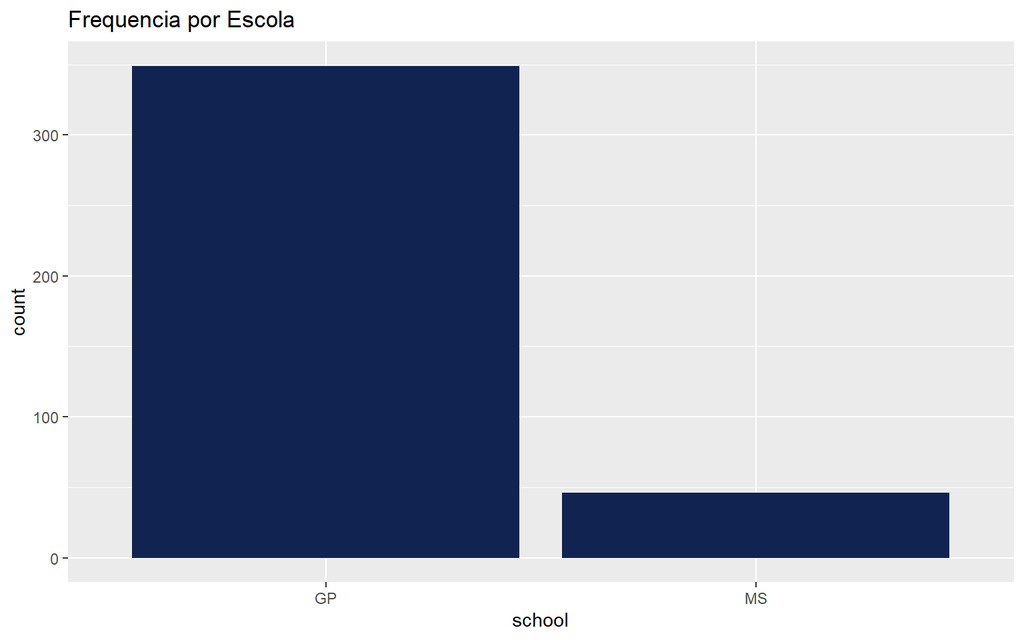

```r
library(corrplot)
library(dplyr)
library(ggplot2)
mat <- read.csv('dados/Maths.csv')
mat[sapply(mat, is.character)] <- lapply(mat[sapply(mat, is.character)],
                                       as.factor)
 mat |> ggplot() +
  aes(school) + geom_bar(fill ='#112350') +
   ggtitle( 'Frequencia por Escola')
```

Cortez, Paulo, e Alice Maria Gonçalves Silva. 2008. "Using data mining to predict secondary school student performance".

[^1]: Universidade Federal do Espírito Santo, samuel.medeiros@edu.ufes.br